# Lab03_ITMD514_Patra_Surajit

Surajit Patra

2024-09-30

# Probability basics

# Sampling Distributions of sums and means

# Normal Distribution

# Sampling Distribution of the Sample Mean from a Normal population

# Law of Large Numbers (LLN)

# Central Limit Theorem (CLT) and the Sampling Distribution of the

# Sample Mean from a non-Normal population

# We will use the sample function extensively so let’s look at its documentation

```r
?sample
help(sample)
library(tidyverse)
```

Example 1: A coin experiment

```r
par(mfrow=c(1,1))
n = 6 #10 #100 #1000 #100000 # number of random experiments; coin flips
x = c(0,1) # sample space for creating a distribution; 0: tails; 1:heads
coin.flips = sample(x, size=n, prob = c(0.2, 0.8), replace=TRUE)
coin.flips
```

```
## [1] 1 1 1 1 1 0
```

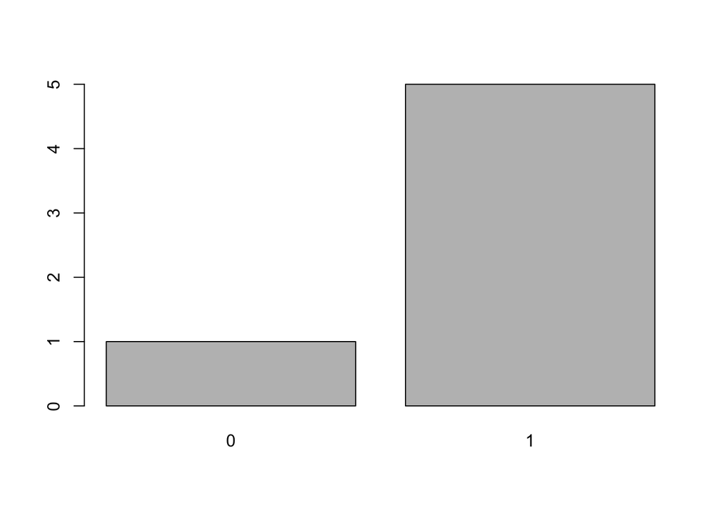

```r
barplot(table(coin.flips)) #plot frequencies
```

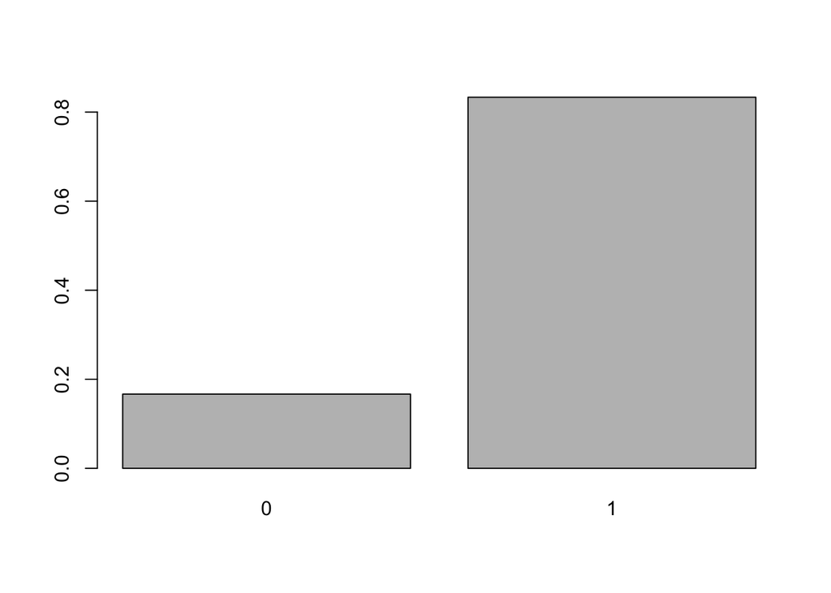

```r
barplot(table(coin.flips)/n) #plot relative frequency
```

Comment: With a fair coin (p = 0.5), the relative frequency of heads and tails fluctuates around 0.5, but with small sample size (n=6), the proportions can vary significantly (e.g., 3 heads and 3 tails, or 4 heads and 2 tails).

With a biased coin (p = 0.8), the relative frequency of heads is expected to be higher. For n = 6, you might get 5 or 6 heads frequently. The variability is still high due to the small sample size, but the distribution skews towards more heads.

# with n=6 coins, we sometimes get 50/50 heads/tails, i.e. sample proportion = .5

# but not always.

# The larger n gets, the more likely we are to observe sample proportion = population proportion.

# experiment by trying different n values above

#We do this below for 6 values of n

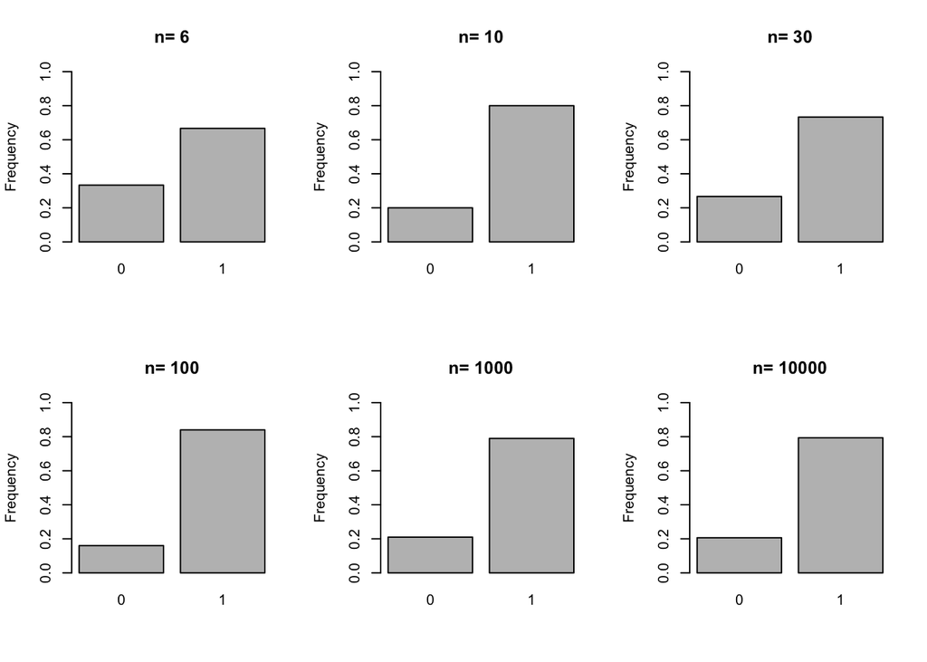

```r
par(mfrow=c(2,3))
x = c(0,1) # sample space for creating a distribution; 0: tails; 1:heads
for (n in c(6,10,30,100,1000,10000)) {
  coin.flips <- sample(x, size=n, prob = c(0.2, 0.8), replace=TRUE)
  barplot(table(coin.flips)/n, main=paste("n=",n), ylab="Frequency", ylim = c(0,1)) #plot relative frequency
}
```

```r
par(mfrow=c(1,1))
```

For n = 6 and 10, the proportion of heads is often closer to 0.8, but still has variability. As n increases to 100, 1000, and 10000, the distribution converges to 0.8.

# At Homework problem: simulate and plot the sample proportions of the coin flips for

# your biased coin

# Now let us calculate a different statistic; the number of heads

```r
n = 10 #10 #100 #1000 #100000 # number of random experiments; coin flips
x = c(0,1) # sample space for creating a distribution; 0: tails; 1:heads
coin.flips = sample(x, size=n, prob = c(0.2, 0.8), replace=TRUE)
Y = sum(coin.flips) # num of heads; a statistic; a function of the data
Y
```

```
## [1] 10
```

Comment: The number of heads (Y) varies around 5 for a fair coin (since p = 0.5 and 10 * 0.5 = 5).

For a biased coin (p = 0.8), Y is expected to be around 8 (since 10 * 0.8 = 8).

```r
N=2000 #100 #1000 #10000
# Repeat the experiment of flipping a coin n times
# and recording the number of heads N times
# i.e. draw N samples of size n each from the fair coin distribution

num.heads.in.N.tries = replicate(
  N,
  sum(sample(x, size=n, prob = c(0.2, 0.8), replace=TRUE))
)
num.heads.in.N.tries
```

[output not shown]

[output cut: 69 more lines]

```r
# let us see the average number of heads in N tries
mean(num.heads.in.N.tries)
```

```
## [1] 7.9675
```

```r
# visualize the distribution of Y
table(num.heads.in.N.tries)
```

```
## num.heads.in.N.tries
##   2   3   4   5   6   7   8   9  10
##   1   1  22  61 180 374 613 545 203
```

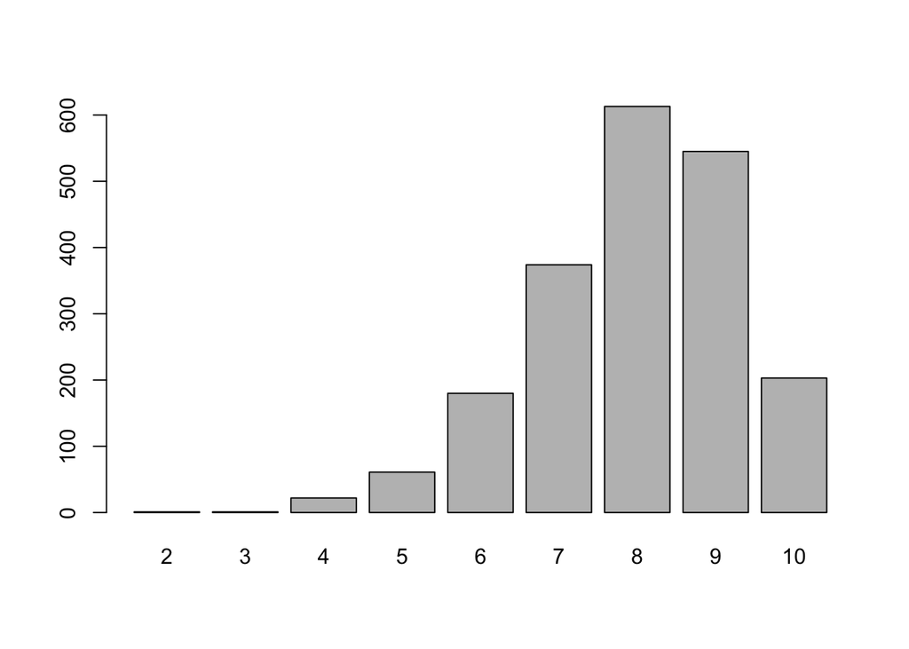

```r
# plot num of heads
barplot(table(num.heads.in.N.tries))
```

Comment: With N = 2000, the mean number of heads stabilizes around 5 for a fair coin.

With p = 0.8, the mean number of heads stabilizes around 8.

# As sample size grows, distribution should look more like normal curve.

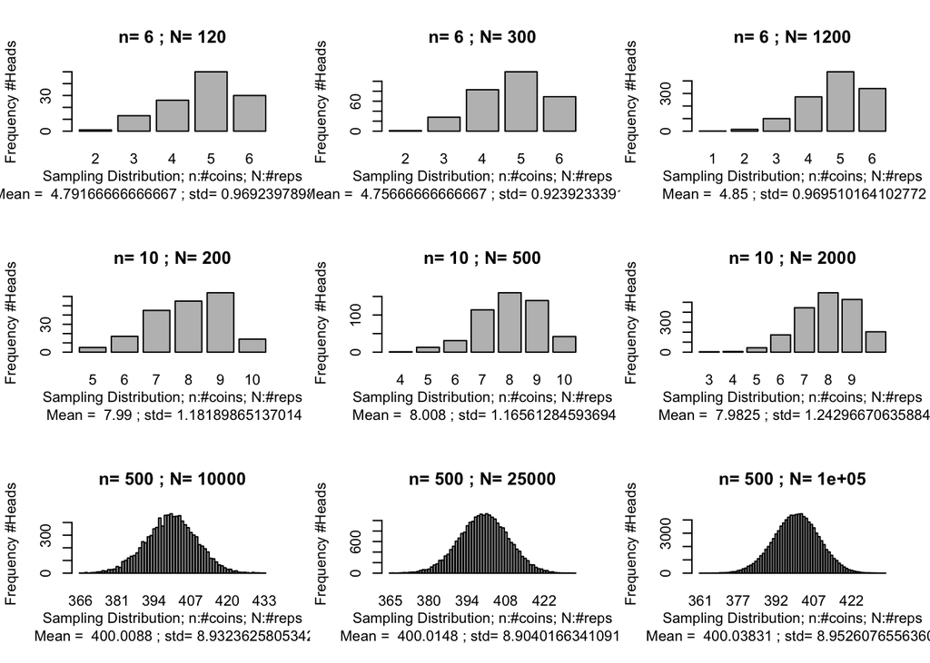

```r
x=c(0,1)
par(mfrow=c(3,3))
for (n in c(6,10,500)) {
  for (N in c(20*n,50*n,200*n)) {
    temp.num.heads = replicate(N, sum(sample(x, size=n, prob = c(0.2, 0.8), replace=TRUE)))
    barplot(table(temp.num.heads),main = paste("n=",n,"; N=", N), ylab=paste("Frequency #Heads"), xlab=paste("Sampling Distribution; n:#coins; N:#reps\n Mean = ", mean(temp.num.heads), "; std=", sd(temp.num.heads)))
  }
}
```

# We do need N to be large enough to be able to simulate enough of the sampling distribution though

# If N is too small, you don’t have enough samples to see the probability structure of the sampling distribution of Y

# Compare these plots to what you already saw in the prior exercise

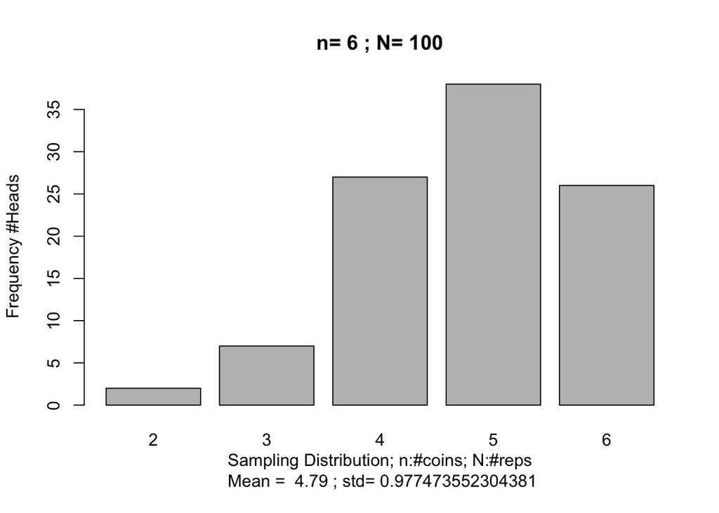

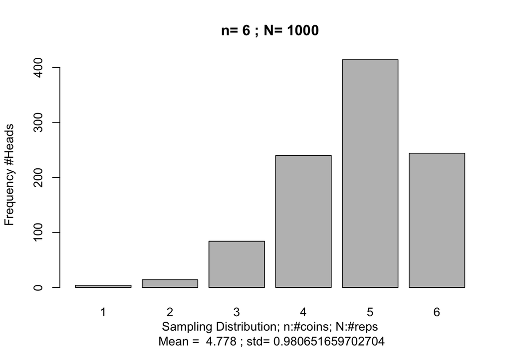

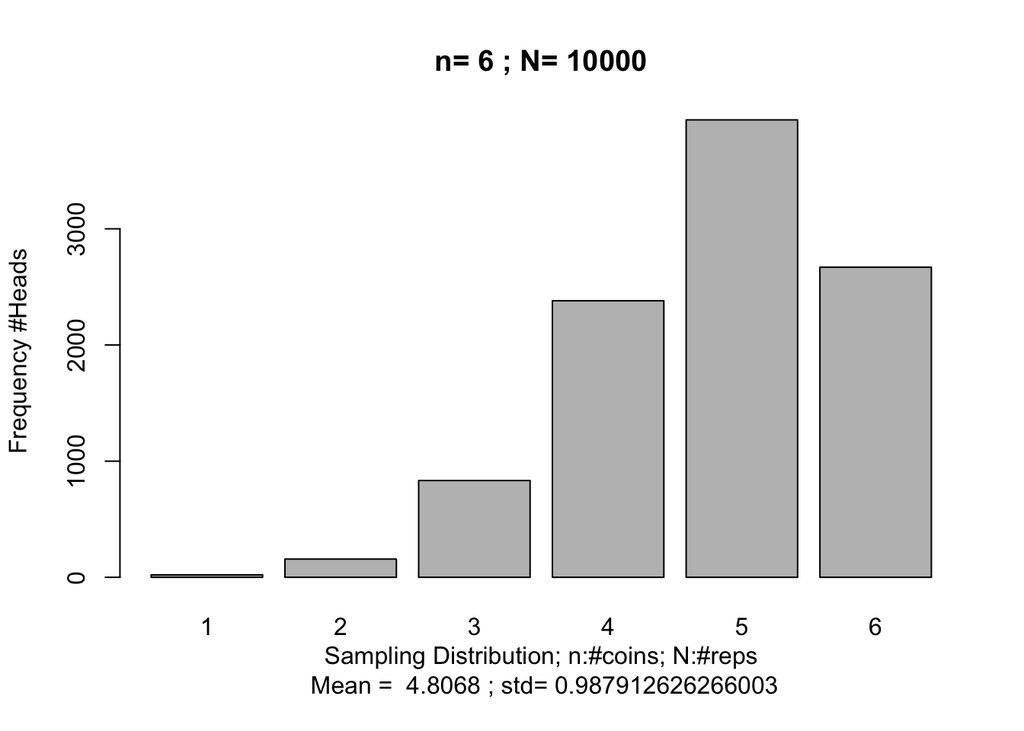

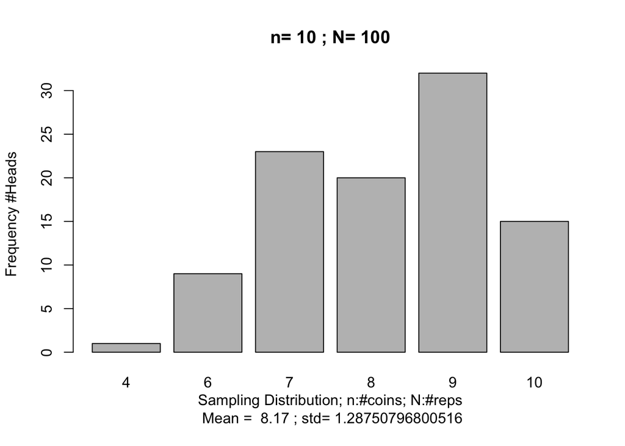

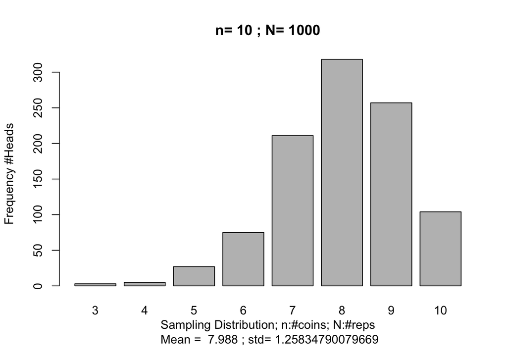

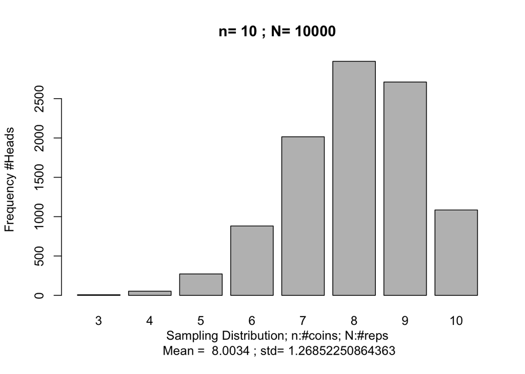

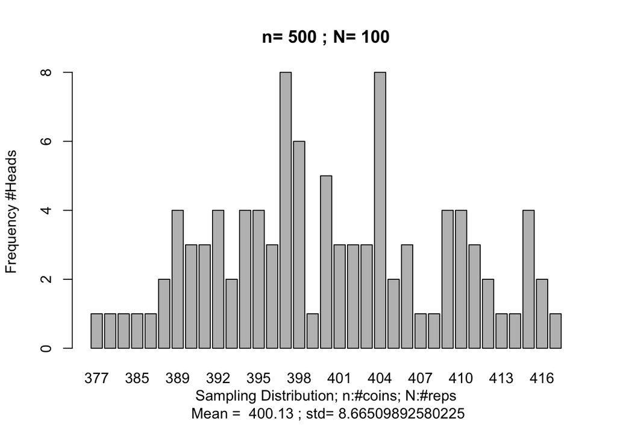

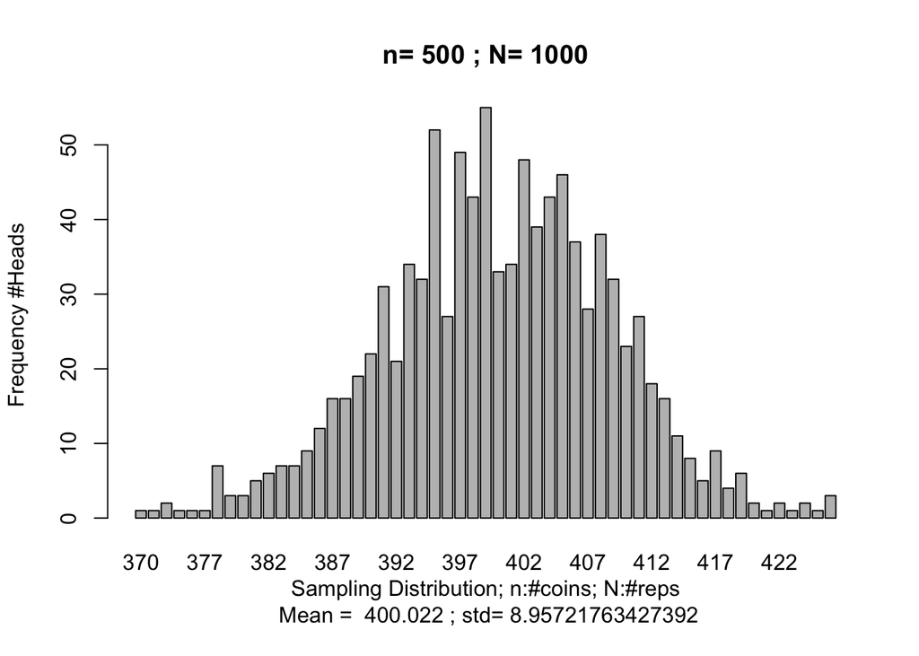

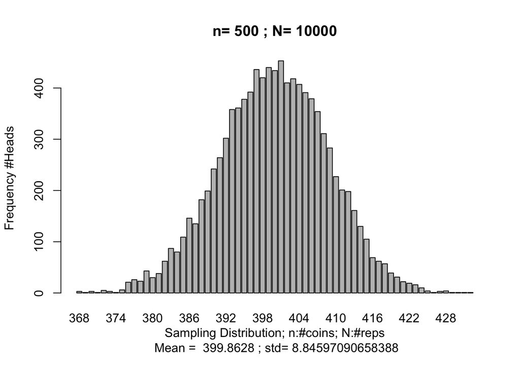

```r
for (n in c(6,10,500)) {
  for (N in c(100,1000,10000)) {
    temp.num.heads = replicate(N, sum(sample(x, size=n, prob = c(0.2, 0.8), replace=TRUE)))
    barplot(table(temp.num.heads),main = paste("n=",n,"; N=", N), ylab=paste("Frequency #Heads"), xlab=paste("Sampling Distribution; n:#coins; N:#reps\n Mean = ", mean(temp.num.heads), "; std=", sd(temp.num.heads)))
  }
}
```

# Let us now use this to visualize the sample mean sampling distribution

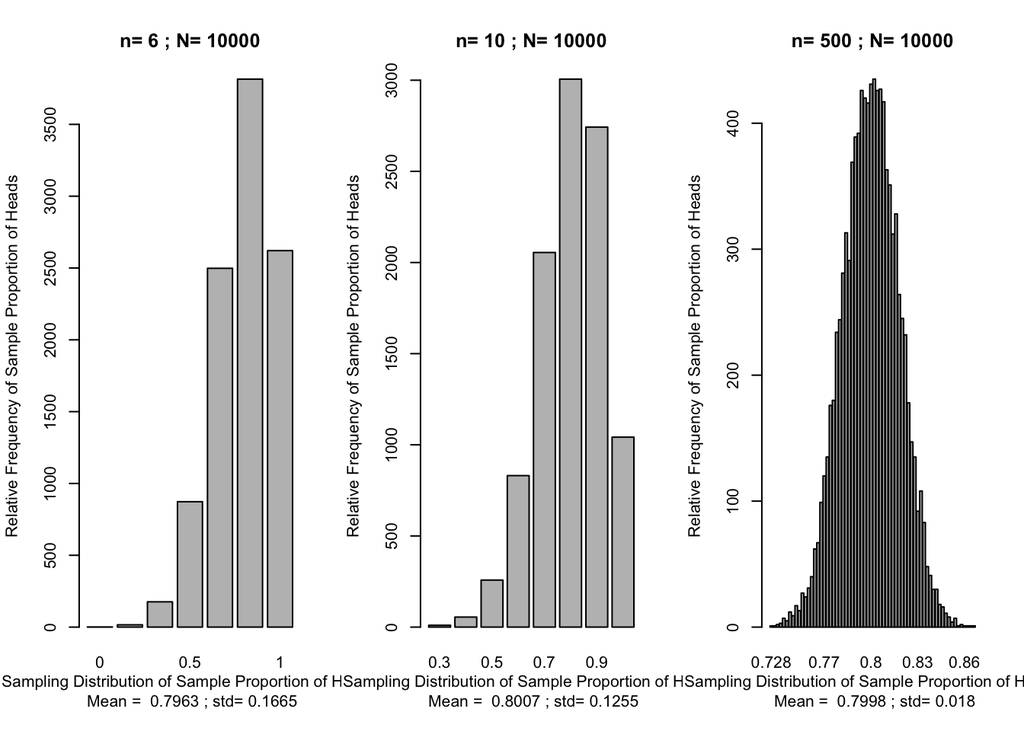

```r
N = 10000
par(mfrow=c(1,3))
for (n in c(6,10,500)) {
    temp.prop.heads = replicate(N, sum(sample(x, size=n, prob = c(0.2,0.8), replace=TRUE))/n)
    barplot(table(temp.prop.heads),main = paste("n=",n,"; N=", N), ylab=paste("Relative Frequency of Sample Proportion of Heads"), xlab=paste("Sampling Distribution of Sample Proportion of Heads\n Mean = ", round(mean(temp.prop.heads),digits=4), "; std=", round(sd(temp.prop.heads),digits=4)))
}
```

```r
par(mfrow=c(1,1))
```

The sample mean stabilizes around 0.8, indicating a higher probability of heads.

# Homework: Repeat this example with your unfair coin. Compare annd contrast your results

Comment: For a biased coin with probablity 0.8 the distribution of the heads is more which means that it is biased towards heads. For a fair coin with heads 0.5 the distribution of heads is symmetric which means that tehre is a 50/50 chance of getting a head or a tail.

Example 2: A u-shaped distribution

# Simulating u-shaped distribution; Sampling Distribution of Sample Mean for a non-nornal r.v.

```r
n = 10 #sample size
current.sample = sample(1:7,prob=c(0.3495,0.1,0.05,0.001, 0.05,0.1,0.3495 ),size=n,replace=TRUE)
current.sample
```

```
##  [1] 7 1 1 1 3 7 6 7 2 7
```

```r
table(current.sample) #frequency table for current sample.
```

```
## current.sample
## 1 2 3 6 7
## 3 1 1 1 4
```

```r
#investigate the sample mean and sample deviation for this sample
x_bar = mean(current.sample)
x_bar
```

```
## [1] 4.2
```

```r
sd(current.sample)
```

```
## [1] 2.820559
```

# To get a good snapshot of the distribution, and see that it is u-shaped, use a large n, i.e, n=10000

```r
n = 10000 #sample size
current.sample = sample(1:7,prob=c(0.3495,0.1,0.05,0.001, 0.05,0.1,0.3495 ),size=n,replace=TRUE)
```

#investigate the sample mean and sample deviation for this sample

```r
x_bar = mean(current.sample)
x_bar
```

```
## [1] 3.9897
```

```r
sd(current.sample)
```

```
## [1] 2.679872
```

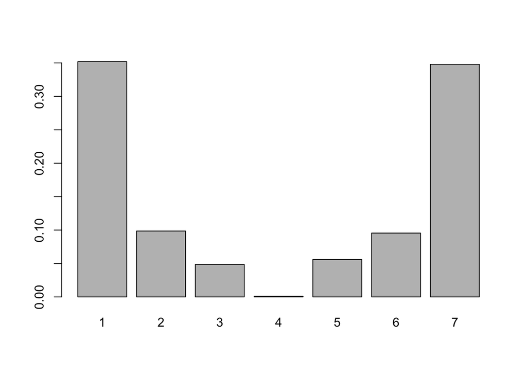

```r
barplot(table(current.sample)/n) #symmetric, but u-shaped distribution
```

#population mean, i.e expected value

```r
sum(c(0.3495,0.1,0.05,0.001, 0.05,0.1,0.3495 ))
```

```
## [1] 1
```

```r
exp_val = sum(1:7*c(0.3495,0.1,0.05,0.001, 0.05,0.1,0.3495 )) # true expected value of r.v.
exp_val # what is the difference between exp_val and x_bar?
```

```
## [1] 4
```

Answer- x_bar= is the mean of a specific sample drawn from the population and exp_val= is the true mean of the population.

#calculate variance, and standard deviation and save then as var_val and sd_val - homework/lab 3

```r
pmf <- c(0.3495,0.1,0.05,0.001, 0.05,0.1,0.3495) # probability mass function
values <- 1:7 # values for the random variable
var_val <- sum(pmf * (values - exp_val)^2) # variance calculation
sd_val <- sqrt(var_val) # standard deviation
var_val
```

```
## [1] 7.191
```

```r
sd_val
```

```
## [1] 2.681604
```

# Investigate the Sampling Distribution of sample mean of a sample of size n from pmf of u-shaped distribution

```r
par(mfrow=c(1,1))
N=1000# samples in sampling distribution
```

#Generate 3 samples of size n

```r
samples = replicate(3, sample(1:7,prob=c(0.3495,0.1,0.05,0.001, 0.05,0.1,0.3495 ),size=n,replace=TRUE))
samples
```

[output not shown]

[output cut: 9986 more lines]

#calculate the 3 sample means for these samples

```r
mean(samples[,1])
```

```
## [1] 3.9921
```

```r
mean(samples[,2])
```

```
## [1] 4.0291
```

```r
mean(samples[,3])
```

```
## [1] 4.0844
```

#simulate 3 sample means

```r
samples.means<- replicate(3, mean(sample(1:7,prob=c(0.3495,0.1,0.05,0.001, 0.05,0.1,0.3495 ),size=n,replace=TRUE)))
samples.means
```

```
## [1] 3.9636 4.0034 4.0441
```

#find their average, variance, and standard deviation

```r
mean.of.means = mean(samples.means)
mean.of.means
```

```
## [1] 4.0037
```

```r
sd.of.means = sd(samples.means)
sd.of.means
```

```
## [1] 0.04025084
```

#compare to the standard deviation of the samples themselves

```r
sd(samples[,1])
```

```
## [1] 2.678536
```

```r
sd(samples[,2])
```

```
## [1] 2.676783
```

```r
sd(samples[,3])
```

```
## [1] 2.674807
```

#Simulate a sampling distribution of the sample mean from N samples of size n

```r
N=10000 #3
n=30
sample.mean.distr = replicate(N, mean(sample(1:7,prob=c(0.3495,0.1,0.05,0.001, 0.05,0.1,0.3495 ),size=n,replace=TRUE)))
sample.mean.distr
```

[output not shown]

[output cut: 1235 more lines]

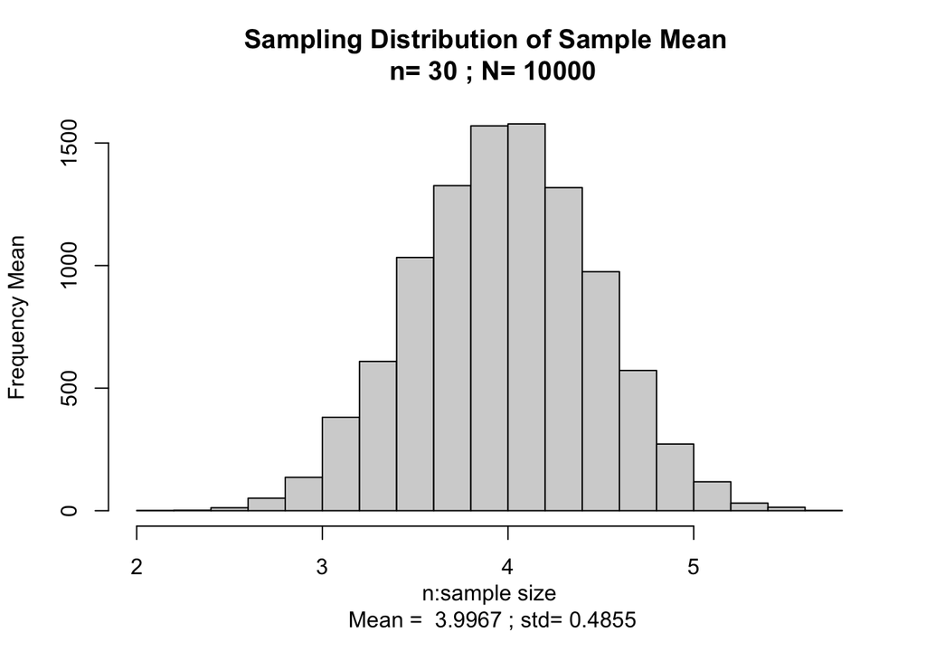

```r
hist(sample.mean.distr,main = paste("Sampling Distribution of Sample Mean \n n=",n,"; N=", N), ylab=paste("Frequency Mean"), xlab=paste("n:sample size\n Mean = ", round(mean(sample.mean.distr),digits=4), "; std=", round(sd(sample.mean.distr),digits=4)))
```

```r
mean.of.means = mean(sample.mean.distr)
mean.of.means
```

```
## [1] 3.99666
```

```r
sd.of.means = sd(sample.mean.distr)
sd.of.means
```

```
## [1] 0.4855496
```